# 4. Jednovýberové parametrické testy

Štatistické metódy vyhodnocovania experimentov

16.3.2021

# Inštrukcie

- Premenná $k$ predstavuje zvyšok vášho poradového čísla po delení 4.
- Všetky výsledky slovne zhodnoťte.
- Automaticky generované slovné odpovede/komentáre nie sú povolené.
- Komentáre v zdrojovom súbore R píšte za znak `#'`, inak je text považovaný za súčasť kódu a nezalomí sa do šírky okna.

# Aplikačné pozadie pre prvé dve úlohy

Na predikciu odolnosti v pretlačení dosky bez šmykovej výstuže (pozri obrázky) sa používa niekoľko modelov. Na overenie presnosti a správnosti modelov sa analyzuje podiel experimentálne zistenej hodnoty $V_{exp}$ a vypočítanej modelovej hodnoty $V_{model}$ pričom má platiť, že $V_{exp} ≥ V_{model}$, t.j.
$$x_i = \frac{V_{exp}}{V_{model}}\geq1.$$
Podiely sú normálne rozdelené. V súbore *modely.xlsx* sú zvlášť uvedené vypočítané modelové hodnoty a experimentálne zistená hodnota.

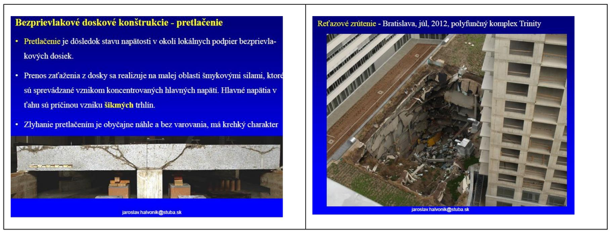

Pretlačenie

# Príklad 1 (bezpečnosť modelu)

**Zadanie:** Graficky zistite aké je rozdelenie vyšetrovaných dát. Vhodným parametrickým testom na hladine významnosti $\alpha = 0.05$ overte, že model je bezpečný. Napíšte nulovú a alternatívnu hypotézu a slovne zhodnoťte výsledky šetrenia (Je príslušný model bezpečný?).

- k = 0, model Eurokód
- k = 1, model MC LoA I
- k = 2, model MC LoA II
- k = 3, model MC LoA III

# Príklad 2 (konzistentnosť modelu)

**Zadanie:** Okrem požiadavky bezpečnosti modelu je v praxi dôležitá aj požiadavka konzistentnosti modelu (materiál, množstvo práce). Odporúča sa, aby disperzia dátového súboru podielov bola ideálne 0.01 a nepresiahla 0.05. Vhodným testom zistite, či príslušné dva modely tieto požiadavky spĺňajú (nutnú a ideálnu). Napíšte nulovú a alternatívnu hypotézu a slovne zhodnoťte výsledky analýzy (Ktorý model by ste preferovali, ak podmienkou by bola táto požiadavka?).

- k = 0, model Eurokód a MC LoA I
- k = 1, model Eurokód a MC LoA II
- k = 2, model Eurokód a MC LoA III
- k = 3, model MC LoA I a MC LoA II

# Príklad 3 (životnosť bateriek)

**Zadanie:** V súbore *data.xlsx* sú zaznamenané údaje o životnosti bateriek (v dňoch) do prístrojov na geotechnický monitoring tunelov a prieskumných štôlní. Dáta sú normálne rozdelené. Vhodným parametrickým testom na hladine významnosti $\alpha = 0.05$ overte pravdivosť tvrdenia príslušného výrobcu a svoje zistenia slovne zhodnoťte. Aká je p-hodnota?

Výrobca X tvrdí, že jeho baterky majú životnosť aspoň Y dní so smerodajnou odchýlkou Z dní.

| k | X | Y | Z |
| --- | --- | --- | --- |
| 0 | A | 46 | 1.0 |
| 1 | B | 45 | 0.5 |
| 2 | C | 45 | 1.2 |
| 3 | D | 47 | 1.0 |